## Species area distributions and their relationship to coexistence mechanisms

I explored how niche and fitness differences influence the shape of SAD curves, using data from Caracoles (2015-19 so far). I estimated coefficients from a Ricker model adapted to annual plants (i.e. using germination and survival coefficients), and generated SAD curves for three different scenarios: one with both niche and fitness differences, one knocking down niche differences, and one knocking down fitness differences.

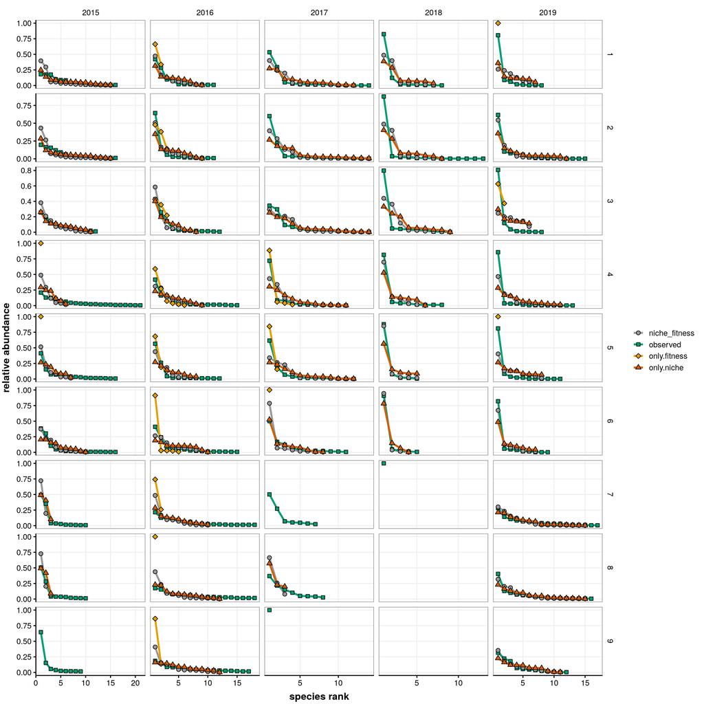

A simple next step is to relate these curves to coexistence patterns. Which species alongside the rank-abundance curves are more likely to coexist? Magurran et al. (2003) showed that empirical SADs can be bi-modal when plotted on log-abundance scale, whereby core species are more abundant and there is a ‘tail’ of transient species. Does the Caracoles system follow this pattern?

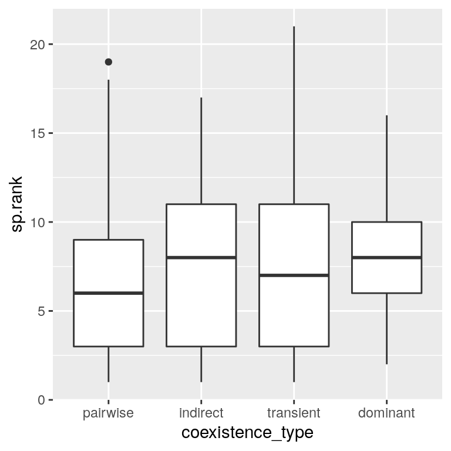

There seem to be no significant differences in rank between species that coexist through pairwise, indirect effects, or transient species. Dominant species appear in the upper set of ranks observed, but well within the variability of the other groups.

Another take on this is to test whether the overall probability of coexistence is related to the species rank. Here I pooled all plots and years and obtained species’ average rank and species’ average probability of coexistence (by any mechanism).

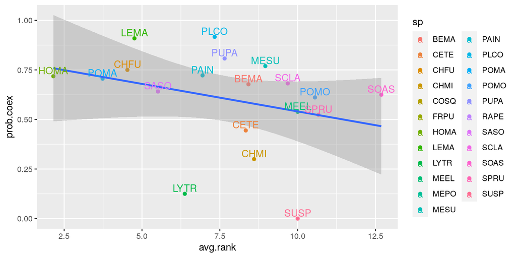

Most dominant species are HOMA, POMA, CHFU, and LEMA. And there is a tendency for rank to be negatively correlated with the probability of coexistence (Pearson’s correlation of -0.310798).